# Final Presentation

Dylan Bordinger

Tuesday, December 07, 2021 @ 09:19 AM

## Setup

### Packages Used

```r
library(tidyverse)
library(readr)
```

## Datasets used

```r
billionaires_2021_10_31 <- read.csv(file = "~/STT2860Project2/STT2860project2/dataraw/billionaires_2021_10_31.csv")

ramenratings <- read_csv("~/STT2860Project2/STT2860project2/dataraw/ramenratings.csv")
```

# Billionaires Grouped By Industry

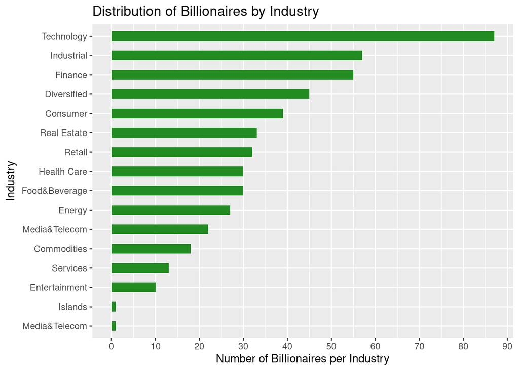

```r
billionaires_by_industry <- billionaires_2021_10_31 %>%
  group_by(Industry) %>%
  summarize(num_bils = n()) %>%
  arrange(desc(num_bils))

ggplot(billionaires_by_industry, aes(reorder(Industry, num_bils), num_bils)) +
  geom_col(width = .5, fill = "forest green") +
  labs(title = "Distribution of Billionaires by Industry") +
  xlab("Industry") +
  ylab("Number of Billionaires per Industry") +
  scale_y_continuous(breaks = seq(0, 100, by = 10)) +
  coord_flip()
```

### I used the group_by and summarize functions to create a new variable for the amount of billionaries per industry. I was originally going to make some sort of graph based on country but the data ended up looking very concentrated in only a few countries out of many listed. I was also personally more interested in seeing what industries tended to produce the most billionaires, rather than country. For some reason there is a stray Media&Telecom billionaire that does not want to group with the rest, power to them.

# The Ramen Ratings

```r
ramenratings1 <- ramenratings %>%
  mutate(stars = as.numeric(stars))
```

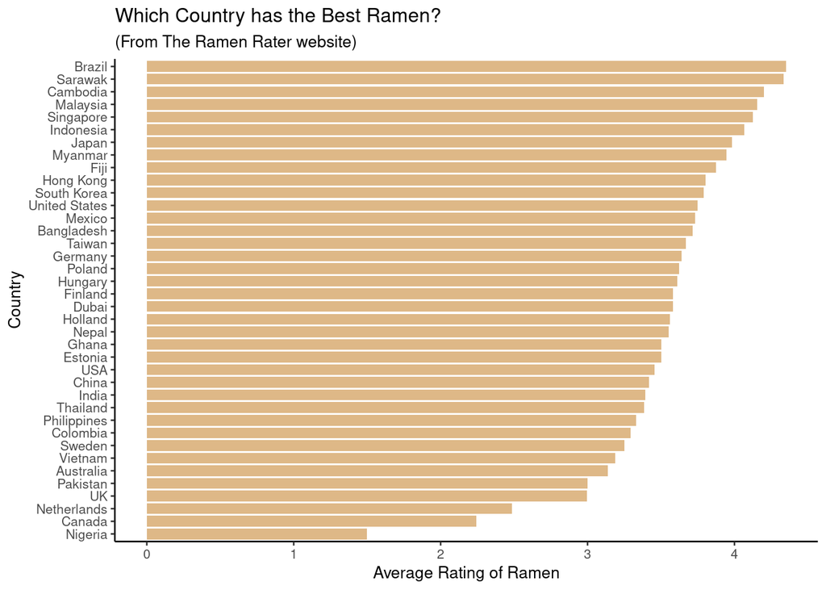

```r
ramenratings2 <- ramenratings1[complete.cases(ramenratings1), ]

ramenratings_by_country <- ramenratings2 %>%
  group_by(country) %>%
  summarize(ratings = mean(stars)) %>%
  arrange(desc(ratings))

ggplot(ramenratings_by_country, aes(reorder(country, ratings), ratings)) +
  geom_col(width = .85, fill = "burlywood") +
  labs(title = "Which Country has the Best Ramen?", subtitle = "(From The Ramen Rater website)") +
  xlab("Country") +
  ylab("Average Rating of Ramen") +
  coord_flip() +
  theme_classic(base_size = 10)
```

### At first I tried looking at the average rating of ramen per style but the results weren’t very interesting, there’s a lot of decent ramen in all styles. When I ended up with this graph based on country, I was surprised to see Brazil on top. It looks like many places in the Eastern and South Asian parts of the world have good ramen, this might be a better chart to look at to know where to avoid if you’re planning on eating some ramen.